# ANOVA

Matthew Johnson

October 26, 2017

1. I chose the data set “diamonds.” I’m doing my analysis on the price of diamonds based on the clarity. Price is in US dollars and clarity is a measurement of how clear the diamond is, I1 is worst, IF is best.

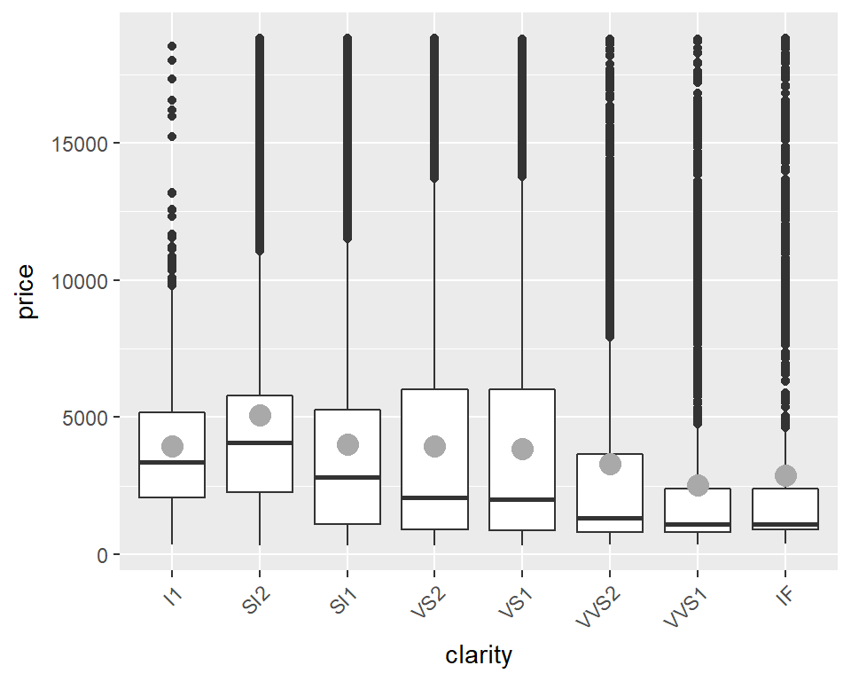

```r
data("diamonds")

p <- qplot(clarity, price, data=diamonds, geom="boxplot") + stat_summary(fun.y=mean, colour="dark gray",
geom="point", size=4) + theme(axis.text.x=element_text(angle=45, hjust=1))
p
```

```r
model <- lm(price~clarity, data=diamonds)
anova(model)
```

```
## Analysis of Variance Table
##
## Response: price
##              Df     Sum Sq    Mean Sq F value    Pr(>F)
## clarity       7 2.3308e+10 3329686126  215.02 < 2.2e-16 ***
## Residuals 53932 8.3517e+11   15485525
## ---
## Signif. codes:  0 '***' 0.001 '**' 0.01 '*' 0.05 '.' 0.1 ' ' 1
```

5. We have an F-value of 215 and our p-value is roughly 2.2e-16, so extremely small. Both of these indicate that we can reject the null hypothesis. Rejection of the null hypothesis indicates to us that the differences in clarity do not have the same mean price. English version: The range of clarities of diamonds do not have the same average price.